# Lista 3 - Funções no R

#### 1. Simule n dados de uma distribuição normal padrão, ou seja, $N(μ = 0, σ = 1)$ e:

**a) utilize a função regra emp para verificar se os dados simulados atendem à regra empírica. Teste com $n=100,1000,10000$**

```r
regra_emp  = function(x, n){
  s1 = sum(x > (mean(x)) - (sd(x)) & x < (mean(x)) + (sd(x)))/n
  s2 = sum(x > (mean(x)) - (2*(sd(x))) & x < (mean(x)) + (2*(sd(x))))/n
  s3 = sum(x > (mean(x)) - (3*(sd(x))) & x < (mean(x)) + (3*(sd(x))))/n
  list(sd1 = s1, sd2 = s2, sd3 =s3)
}
n = 100
regra_emp(rnorm(n), n)
```

```
## $sd1
## [1] 0.69
##
## $sd2
## [1] 0.97
##
## $sd3
## [1] 0.99
```

```r
n = 1000
regra_emp(rnorm(n), n)
```

```
## $sd1
## [1] 0.69
##
## $sd2
## [1] 0.954
##
## $sd3
## [1] 0.996
```

```r
n = 10000
regra_emp(rnorm(n), n)
```

```
## $sd1
## [1] 0.6822
##
## $sd2
## [1] 0.9542
##
## $sd3
## [1] 0.9979
```

**b) Obtenha o QQplot dos dados simulados.**

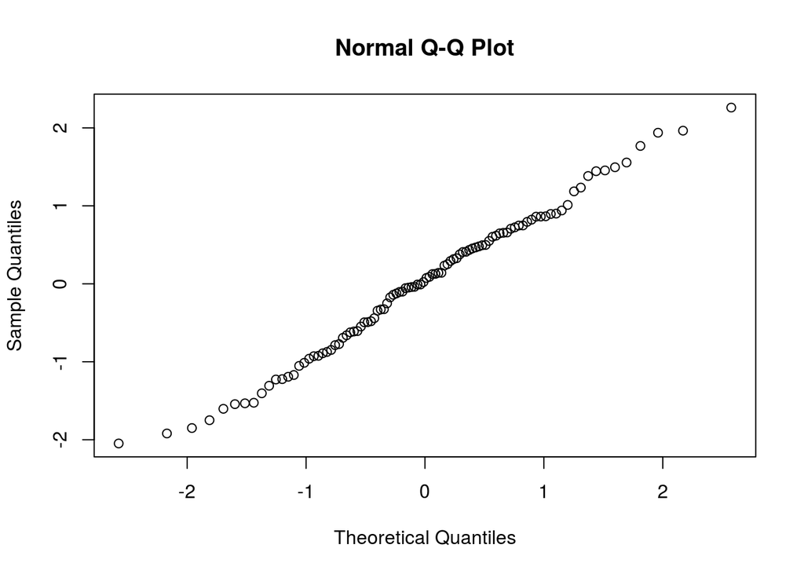

```r
n = 100
qqnorm(rnorm(n))
```

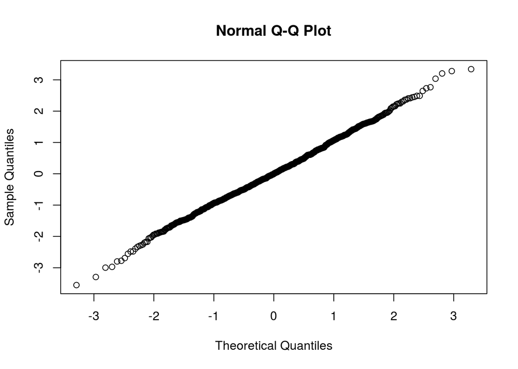

```r
n = 1000
qqnorm(rnorm(n))
```

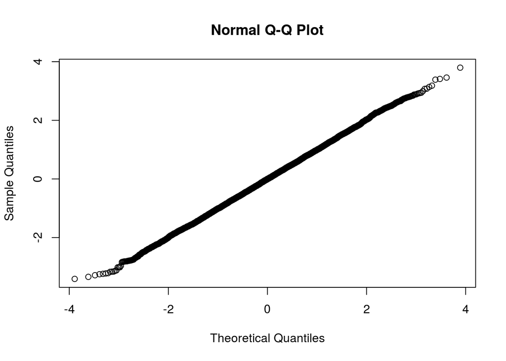

```r
n = 10000
qqnorm(rnorm(n))
```

#### 2. Modificar a função moeda com n lançamentos para que as ocorrências sejam “C” (cara) e “K” (coroa) e que:

**a) além dos resultados “C” e “K”, a função também retorne as frequências dos resultados (absolutas e relativas - podendo-se usar o comando table para isso).**

```r
moeda = function(n){
  a = sample(c("C","K"), n, rep=T)
  b =table(a)
  c = table(a)/n
  list(amostra=a, freq_absoluta=b, freq_relativa=c)
}
moeda(100)$amostra
```

```
##   [1] "C" "C" "C" "C" "K" "K" "K" "K" "K" "K" "K" "C" "C" "K" "K" "K" "C"
##  [18] "K" "C" "K" "C" "K" "C" "C" "K" "C" "C" "C" "K" "C" "K" "K" "K" "K"
##  [35] "C" "C" "C" "K" "K" "K" "K" "C" "C" "C" "K" "K" "C" "K" "C" "C" "C"
##  [52] "K" "K" "C" "C" "C" "K" "K" "K" "K" "K" "C" "C" "C" "K" "C" "C" "C"
##  [69] "C" "K" "K" "C" "C" "C" "C" "C" "C" "C" "C" "K" "C" "K" "K" "K" "K"
##  [86] "C" "K" "C" "K" "K" "C" "K" "K" "C" "K" "K" "K" "C" "C" "C"
```

**b) depois de usar a função, faça um gráfico de barras usando o resultado dos lançamentos da moeda com $n = 100$ e $n = 1000$.**

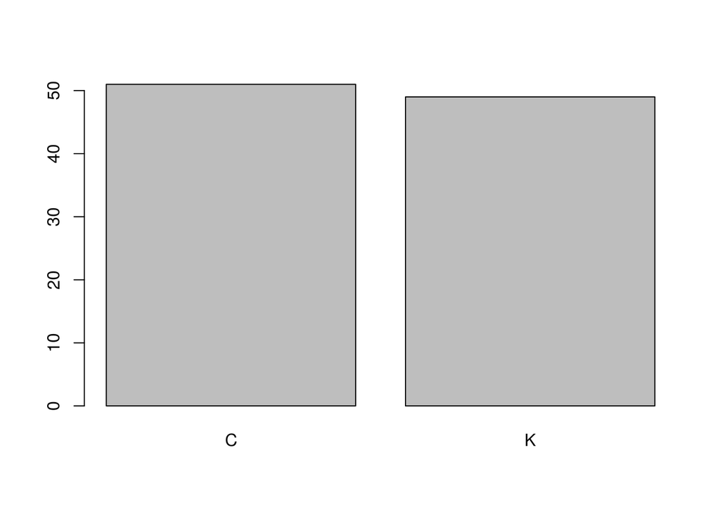

```r
barplot(table(moeda(100)$amostra))
```

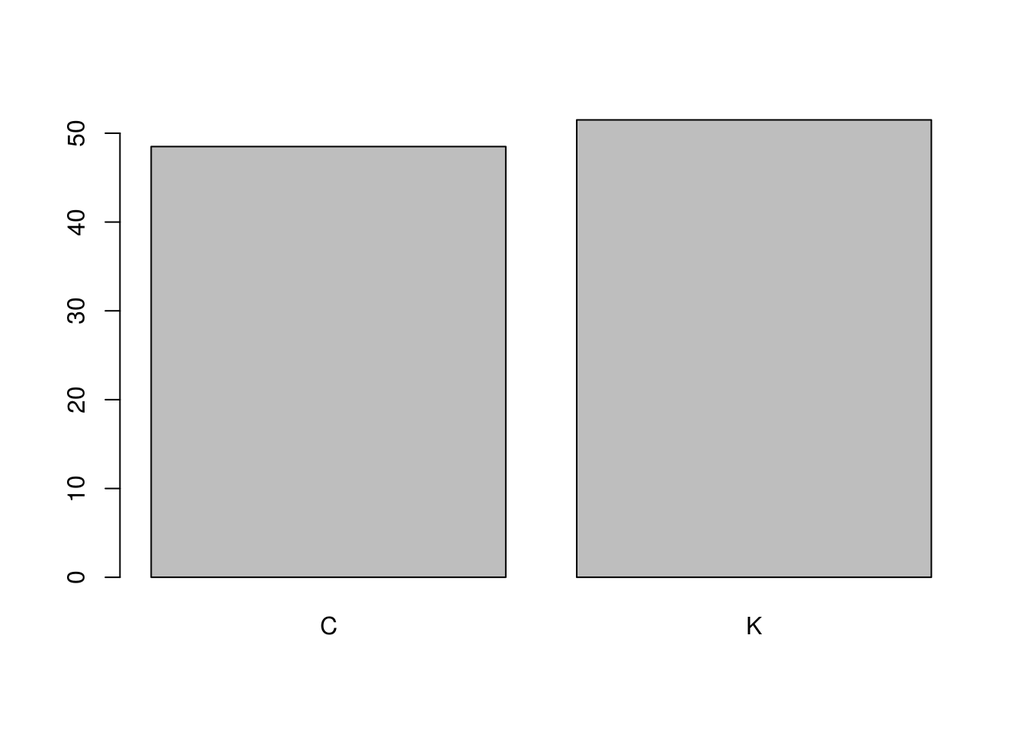

```r
barplot(table(moeda(1000)$amostra)/1000 * 100)
```

#### 3. Criar a função dado que permita lançar um dado $n$ vezes e:

**a) tenha o mesmo retorno da função anterior.**

```r
dado = function(n){
  a = sample(1:6, n, replace = T)
  b =table(a)
  c = table(a)/n
  list(amostra=a, freq_absoluta=b, freq_relativa=c)
}
```

**b) compare com as probabilidades teóricas.**

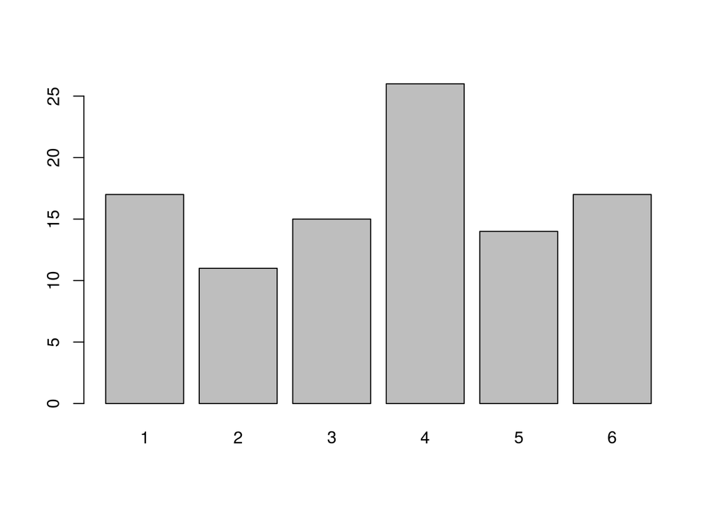

```r
n = 100
barplot(table(dado(n)$amostra)/n * 100)
```

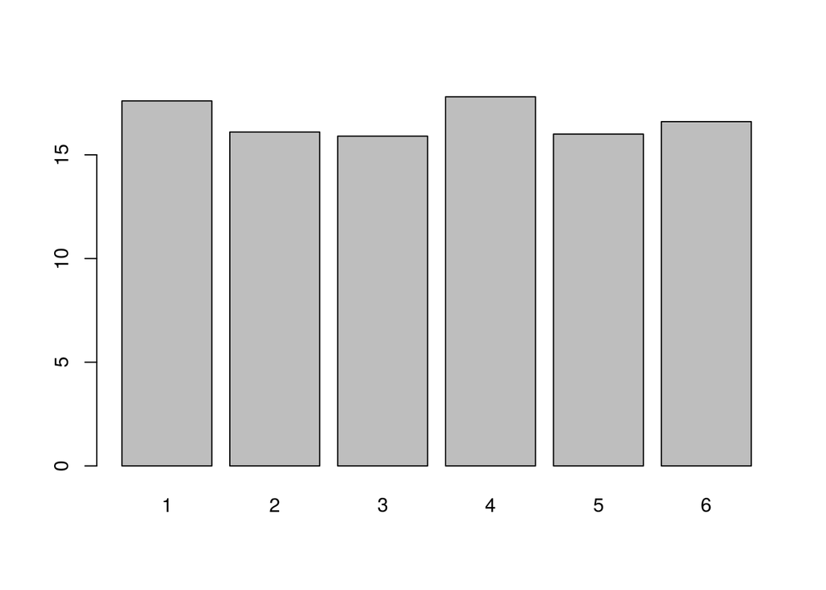

```r
n = 1000
barplot(table(dado(n)$amostra)/n * 100)
```

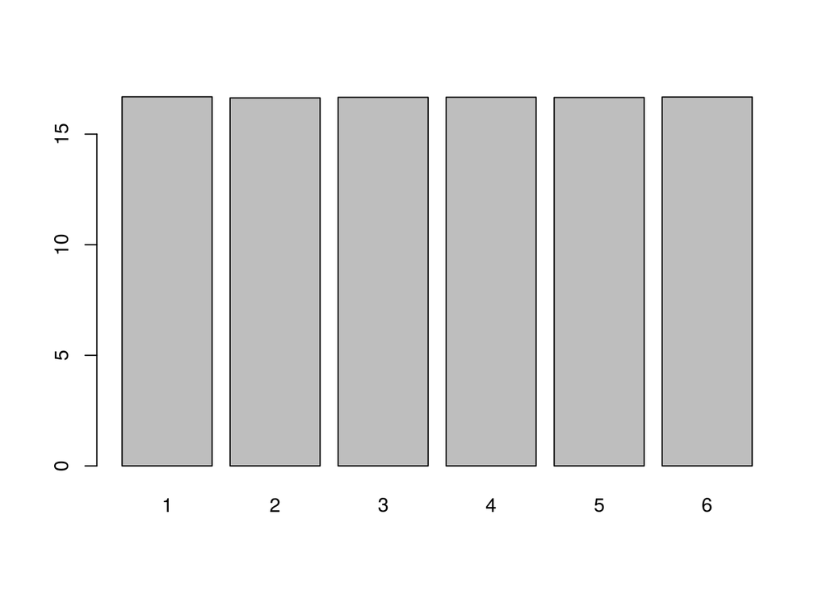

```r
n = 10000000
barplot(table(dado(n)$amostra)/n * 100)
```

#### 4. Construir uma função para verificar quantos elementos de um vetor de dimensão n são menores ou iguais a uma constante $k$, real. Utilize as estruturas de repetição `for`, `while` e `repeat` para realizar tal tarefa (cada uma destas estruturas deverá ser implementada em uma diferente função).

```r
vetor = c(2,5,4,6,8,7,9,4,5,88,77,5,58,6,52,45)

confor = function(v, k){
  c = 0
  for(i in 1:length(v)){
    if(v[i] <= k){
      c = c + 1
    }
  }
  print(c)
}

confor(vetor, 5)
```

```
## [1] 6
```

```r
conwhile = function(v,k){
  c = 0
  i = 1
  while(i <= length(v)){
    if(v[i] <= k){
      c = c + 1
    }
    i = i + 1
  }
  print(c)
}

conwhile(vetor, 5)
```

```
## [1] 6
```

```r
conrepeat = function(v,k){
  c = 0
  i = 1
  repeat{
    if(v[i] <= k){
      c = c + 1
    }
    i = i + 1
    if(i >= length(v)) break
  }
  print(c)
}

conrepeat(vetor,5)
```

```
## [1] 6
```

#### 5. Sobre a função `matrizA`:

**a) generalize-a criando a função matrizA1 que aceite matrizes retangulares, ou seja, não quadradas e teste para: $3 × 3, 5 × 8, 1 × 4$.**

```r
matrizA1 = function(r,c){
  A = matrix(0,r,c)
  for(i in 1:r){
    for(j in 1:c){
      if(i == j){
        A[i,j] = i * j
      }else{
        A[i,j] = i + j
      }
    }
  }
return(A)
}
matrizA1(3,3)
```

```
##      [,1] [,2] [,3]
## [1,]    1    3    4
## [2,]    3    4    5
## [3,]    4    5    9
```

```r
matrizA1(5,8)
```

```
##      [,1] [,2] [,3] [,4] [,5] [,6] [,7] [,8]
## [1,]    1    3    4    5    6    7    8    9
## [2,]    3    4    5    6    7    8    9   10
## [3,]    4    5    9    7    8    9   10   11
## [4,]    5    6    7   16    9   10   11   12
## [5,]    6    7    8    9   25   11   12   13
```

```r
matrizA1(1,4)
```

```
##      [,1] [,2] [,3] [,4]
## [1,]    1    3    4    5
```

**b) Inclua na função a saída que contenha a soma dos elementos dessa matriz. Assim, ao executar a função, a saída deve ser o obleto `A` e o objeto `soma`.**

```r
matrizA1S = function(r,c){
  A = matrix(0,r,c)
  soma = 0
  for(i in 1:r){
    for(j in 1:c){
      if(i == j){
        A[i,j] = i * j
      }else{
        A[i,j] = i + j
      }
      soma = soma + A[i,j]
    }
  }
  list(A=A, soma=soma)
}
matrizA1S(3,3)
```

```
## $A
##      [,1] [,2] [,3]
## [1,]    1    3    4
## [2,]    3    4    5
## [3,]    4    5    9
##
## $soma
## [1] 38
```

```r
matrizA1S(5,8)
```

```
## $A
##      [,1] [,2] [,3] [,4] [,5] [,6] [,7] [,8]
## [1,]    1    3    4    5    6    7    8    9
## [2,]    3    4    5    6    7    8    9   10
## [3,]    4    5    9    7    8    9   10   11
## [4,]    5    6    7   16    9   10   11   12
## [5,]    6    7    8    9   25   11   12   13
##
## $soma
## [1] 325
```

```r
matrizA1S(1,4)
```

```
## $A
##      [,1] [,2] [,3] [,4]
## [1,]    1    3    4    5
##
## $soma
## [1] 13
```

#### 6. Suponha que $X$ tenha a função densidade de probabilidade $f(x) = 3x 2 , 0 < x < 1$. Crie a função `f` para retornar essa $f.d.p.$ Faça o que se pede:

```r
f = function(x){
  fx = ifelse((0 < x & x < 1), (3 * x^2), 0)
  return(fx)
}

f(0.8)
```

```
## [1] 1.92
```

**a) verifique que $f(x)$ é uma $f.d.p.$**

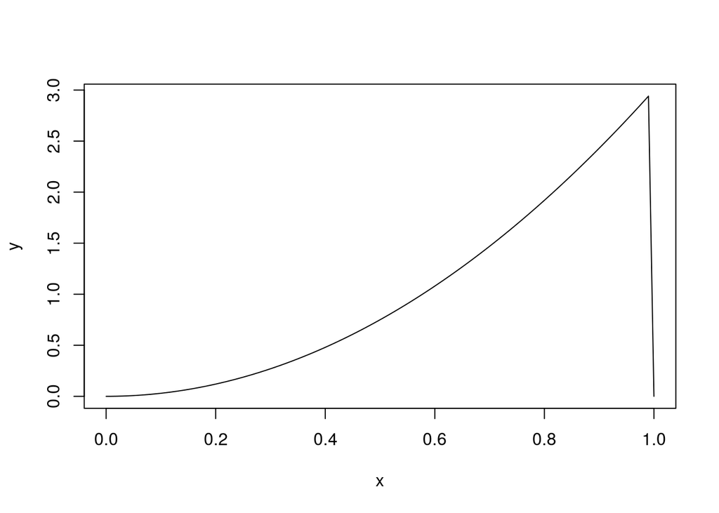

```r
curve(f(x), from = 0, to = 1, ylab = "y")
```

```r
integrate(f, -Inf, Inf)
```

```
## 1 with absolute error < 7.2e-08
```

**b) obtenha o valor de $f(0, 5)$.**

```r
f(0.5)
```

```
## [1] 0.75
```

**c) calcule o valor de $P(0, 14 ≤ X ≤ 0, 71)$. Use a função `integrate`.**

```r
integrate(f, 0.14, 0.71)
```

```
## 0.355167 with absolute error < 3.9e-15
```

**d) sabendo que $f(x)$ é uma distribuição beta com parâmetros $α = 3$ e $β = 1$, obtenha o histograma de uma amostra de tamanho $n = 1000$ dessa distribuição usando a função pronta do R `rbeta`.**

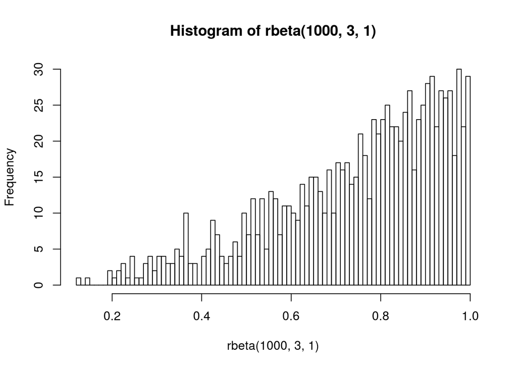

```r
hist(rbeta(1000, 3, 1), 100)
```

**e) compare o resultado de b com o da função do R `dbeta`.**

```r
f(0.5)
```

```
## [1] 0.75
```

```r
dbeta(0.5,3,1)  # ???? Quais parâmetros da beta???
```

```
## [1] 0.75
```

**f) compare o resultado de c com os valores obtidos por meio da função `pbeta`.**

```r
integrate(f, 0.14, 0.71)
```

```
## 0.355167 with absolute error < 3.9e-15
```

```r
integrate(pbeta, 0.14, 0.71, 3, 1)  # ????Quais parâmetros da beta???
```

```
## 0.06343316 with absolute error < 7e-16
```

#### 7. Sabendo que $X$ segue uma distribuição normal com média $μ$ e desvio padrão $σ$, sua $f.d.p.$ é:

$$f(x)= \frac{1}{\sigma \sqrt{2\pi}}\exp\bigg(-\frac{1}{2}\frac{(x-\mu)^2}{\sigma^2} \bigg),-\infty<x<\infty.$$

**a) Construa a função `normal` para retornar a $f.d.p.$ de uma distribuição normal com quaisquer valores de $μ$ e $σ$.**

```r
normal = function(x, mean, sd){
  fx = (1/(sd * sqrt(2*pi)))*exp((-1/2)*(((x-mean)^2)/(sd^2)))
  return(fx)
}
```

**b) Obtenha o valor da $f.d.p.$ no ponto $x = 5$ para uma normal com $μ = 4$ e $σ = 1$ usando sua função. Compare seu resultado com a função pronta do R.**

```r
normal(5,4,1)
```

```
## [1] 0.2419707
```

```r
dnorm(5,4,1)
```

```
## [1] 0.2419707
```

**c) Calcule $P(X ≥ 4)$ para os parâmetros da letra b. Qual deve ser o resultado?**

```r
integrate(normal, 4, Inf, mean=4, sd=1)
```

```
## 0.5 with absolute error < 4.7e-05
```

```r
integrate(dnorm, 4, Inf, mean=4, sd=1)
```

```
## 0.5 with absolute error < 4.7e-05
```